# Data Science Specialization - Capstone Project - Milestone project

Ramiro Alvite Diaz

2018-03-29

## Overview

In this capstone we will be applying data science in the area of natural language processing.

Dataset

The data is from a corpus called HC Corpora.

After extracting the downloaded zip file, we end up with four sets of three files:

- aa_AA.blogs.txt: text obtained from blogs
- aa_AA.news.txt: text obtained from news feeds
- aa_AA.twitter.txt: text obtained from Twitter

Where aa_AA denotes language and locale and is either `de_DE` (German), `en_US` (English, US), `fi_FI` (Finnish) or `ru_RU` (Russian).

[Capstone dataset](https://d396qusza40orc.cloudfront.net/dsscapstone/dataset/Coursera-SwiftKey.zip)

```r
# url <- "https://d396qusza40orc.cloudfront.net/dsscapstone/dataset/Coursera-SwiftKey.zip"
# #dir.create("./data_raw")
# f <- file.path(getwd(), "./data_raw/Coursera-SwiftKey.zip")
# download.file(url, f)
# unzip(f)
```

## Tasks to accomplish

1. The first step is to import these texts into one’s favorite computing environment, in our case R and organize and structure the texts to be able to access them in a uniform manner
2. Transformation. The second step is tidying up the texts, including preprocessing the texts to obtain a convenient representation for later analysis. This step might involve
   - lowercase conversion
   - removing punctuation marks
   - removing numbers
   - text reformatting (e.g., extra whitespace removal)
   - stopword removal
   - stemming procedures
3. Transform the preprocessed texts into structured formats to be actually computed with. For classical text mining tasks, this normally implies the creation of a so-called term-document matrix
4. Wwork and compute on texts with standard techniques from statistics and data mining, like clustering or classification methods

Thus there is a need for a conceptual entity similar to a database holding and managing text documents in a generic way: we call this entity a text **document collection** or **corpus**

## Data load

```r
raw_data_dir <- "./data_raw/final/en_US/"
samplingFile <- function(filename, prob) {
    incon <- file(paste(raw_data_dir, "en_US.", filename, ".txt",sep=""),"r")
    file <- readLines(incon)
    # sampling by rbinom()
    set.seed(123)
    sample_file <- file[rbinom(n = length(file), size = 1, prob = prob) == 1]
    close(incon)

    # Write out the sample file to the local file to save it
    outCon <- file(paste(raw_data_dir, "sample_", filename, ".txt",sep=""), "w")
    writeLines(sample_file, con = outCon)
    close(outCon)
}

samplingFile("blogs", 0.02)
samplingFile("news", 0.1)
samplingFile("twitter", 0.01)

# remove non-ASCII encoding
text_file <- paste(raw_data_dir,"sample_news.txt",sep = "")
conn <- conn <- file(text_file, "r")
newsData <- readLines(conn)
close(conn)

text_file <- paste(raw_data_dir,"sample_blogs.txt",sep = "")
conn <- conn <- file(text_file, "r")
blogsData <- readLines(conn)
close(conn)


text_file <- paste(raw_data_dir,"sample_twitter.txt",sep = "")
conn <- conn <- file(text_file, "r")
twitterData <- readLines(conn)
close(conn)


encodingASCII <- function(inputData, print=FALSE){
    inputData <- lapply(inputData, function(row) iconv(row, "latin1", "ASCII", sub=""))
    return(unlist(inputData))
}

cleanData = encodingASCII(paste(newsData, blogsData, twitterData))

# create VCorpus
lang = "en"
vs <- VectorSource(cleanData)
corpus.sample <- VCorpus(vs, readerControl=list(readPlain, language=lang, load=TRUE))
```

### Basics summaries of files

```r
fileInformation <- function(filepath) {
  size <- file.info(filepath)$size/1048576

  conn <- file(filepath, "r")
  fulltext <- readLines(conn, encoding="UTF-16LE")
  nlines <- length(fulltext)

  maxline <- 0
  for (i in 1:nlines) {
    linelength <- nchar(fulltext[i])
    if (linelength > maxline) { maxline <- linelength }
  }
  close(conn)

  infotext <- paste0("File: ", filepath, ", ",
                     "size: ", sprintf("%.1f", size), " MB, ",
                     "number of lines: ", nlines, ", ",
                     "max line length: ", maxline, " characters")

  # create a list with object properties to access them
  list(size=size, nlines=nlines, maxline=maxline, infotext=infotext)
}

blog_info <- fileInformation(paste0(raw_data_dir,"en_US.blogs.txt"))
news_info <- fileInformation(paste0(raw_data_dir,"en_US.news.txt"))
twit_info <- fileInformation(paste0(raw_data_dir,"en_US.twitter.txt"))

blog_info$infotext
```

```
## [1] "File: ./data_raw/final/en_US/en_US.blogs.txt, size: 200.4 MB, number of lines: 899288, max line length: 40835 characters"
```

```r
news_info$infotext
```

```
## [1] "File: ./data_raw/final/en_US/en_US.news.txt, size: 196.3 MB, number of lines: 77259, max line length: 5760 characters"
```

```r
twit_info$infotext
```

```
## [1] "File: ./data_raw/final/en_US/en_US.twitter.txt, size: 159.4 MB, number of lines: 2360148, max line length: 213 characters"
```

### Data preprocessing

```r
# to lowercase
corpus.sample <- tm_map(corpus.sample, content_transformer(tolower))

# remove URL
removeURL <- function(x) gsub("http[^[:space:]]*", "", x)
corpus.sample <- tm_map(corpus.sample, content_transformer(removeURL))

# remove extra whitespaces
corpus.sample <- tm_map(corpus.sample, stripWhitespace)
# remove punctuations
corpus.sample <- tm_map(corpus.sample, removePunctuation)
# remove numbers
corpus.sample <- tm_map(corpus.sample, removeNumbers)



# remove anything other than English letters or space
removeNoiseChars <- function(x) gsub("[^[:alpha:][:space:]]", "", x)
corpus.sample <- tm_map(corpus.sample, content_transformer(removeNoiseChars))

# stopword removal
corpus.sample <- tm_map(corpus.sample, removeWords, stopwords("english"))
```

In many applications, words need to be stemmed to retrieve their radicals, so that various forms derived from a stem would be taken as the same when counting word frequency. This can be achieved with `stemDocument()` function.

```r
corpus.sample <- tm_map(corpus.sample, stemDocument)
```

### Data exploration

Firstly, we have a look at the documents numbered 11 to 15 in the built corpus.

```r
inspect(corpus.sample[11:15])
```

```
## <<VCorpus>>
## Metadata:  corpus specific: 0, document level (indexed): 0
## Content:  documents: 5
##
## [[1]]
## <<PlainTextDocument>>
## Metadata:  7
## Content:  chars: 394
##
## [[2]]
## <<PlainTextDocument>>
## Metadata:  7
## Content:  chars: 173
##
## [[3]]
## <<PlainTextDocument>>
## Metadata:  7
## Content:  chars: 121
##
## [[4]]
## <<PlainTextDocument>>
## Metadata:  7
## Content:  chars: 241
##
## [[5]]
## <<PlainTextDocument>>
## Metadata:  7
## Content:  chars: 400
```

One of the simplest analysis methods in text mining is based on count-based evaluation. This means that those terms with the highest occurrence frequencies in a text are rated important.

#### Building a Document Term Matrix

A term-document matrix represents the relationship between terms and documents, where each row stands for a term and each column for a document, and an entry is the number of occurrences of the term in the document. It can be exported from a Corpus and is used as a bag-of-words mechanism which means that the order of tokens is irrelevant.

```r
TDM <- TermDocumentMatrix(corpus.sample)
TDM
```

```
## <<TermDocumentMatrix (terms: 46130, documents: 23512)>>
## Non-/sparse entries: 1005319/1083603241
## Sparsity           : 100%
## Maximal term length: 110
## Weighting          : term frequency (tf)
```

```r
TDM <- removeSparseTerms(TDM, sparse = 0.95)
TDM
```

```
## <<TermDocumentMatrix (terms: 91, documents: 23512)>>
## Non-/sparse entries: 194488/1945104
## Sparsity           : 91%
## Maximal term length: 6
## Weighting          : term frequency (tf)
```

#### Frequent terms and associations

In the code below, the function `findFreqTerms()` finds frequent terms with frequency more than a given thereshold. Note that they are ordered alphabetically, instead of by frequency or popularity.

```r
TDMHighFreq <- findFreqTerms(TDM, lowfreq = 50)
sort(TDMHighFreq)
```

```
##  [1] "also"   "anoth"  "around" "back"   "best"   "call"   "can"
##  [8] "cant"   "citi"   "come"   "day"    "didnt"  "dont"   "end"
## [15] "even"   "feel"   "find"   "first"  "follow" "friend" "game"
## [22] "get"    "give"   "good"   "got"    "great"  "help"   "home"
## [29] "hope"   "includ" "just"   "keep"   "know"   "last"   "let"
## [36] "life"   "like"   "littl"  "live"   "look"   "lot"    "love"
## [43] "made"   "make"   "mani"   "may"    "much"   "need"   "never"
## [50] "new"    "next"   "night"  "now"    "one"    "peopl"  "place"
## [57] "play"   "point"  "put"    "realli" "right"  "run"    "said"
## [64] "say"    "school" "see"    "show"   "sinc"   "someth" "start"
## [71] "state"  "still"  "take"   "thank"  "that"   "thing"  "think"
## [78] "three"  "time"   "today"  "tri"    "two"    "use"    "want"
## [85] "way"    "week"   "well"   "will"   "work"   "world"  "year"
```

```r
# top frequent number
N <- 10
m <- as.matrix(TDM)
m_dim <- dim(m)
topTokens <- sort(rowSums(m), decreasing=TRUE)[1:N]
topTokens
```

```
## said will  one like just  get time  can year make
## 6944 6677 6418 5684 5461 5262 5060 4863 4630 4005
```

The matrix elements are term frequencies. The resulting matrix dimension is 91, 23512. The reason of its large dimension is the extremely sparse internal structure since most combinations of documents and terms are zero.

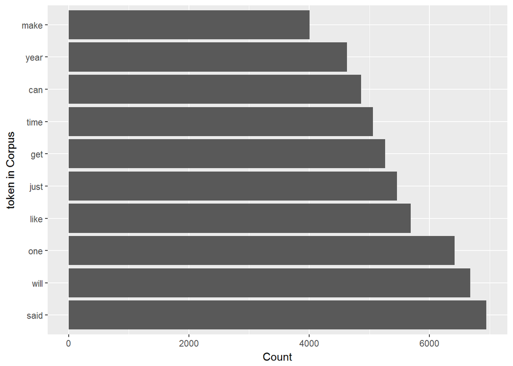

```r
library(reshape2)
library(ggplot2)

dfplot <- as.data.frame(melt(topTokens))
dfplot$token <- dimnames(dfplot)[[1]]
dfplot$token <- factor(dfplot$token,
                      levels=dfplot$token[order(dfplot$value,
                                               decreasing=TRUE)])

fig <- ggplot(dfplot, aes(x=token, y=value)) + geom_bar(stat="identity")
fig <- fig + xlab("token in Corpus")
fig <- fig + ylab("Count")
fig <- fig + coord_flip()
print(fig)
```

#### 2-gram tockens extraction

```r
N <- 10
BigramTokenizer <- function(x) NGramTokenizer(x, Weka_control(min = 2, max = 2))
TDM2 <- TermDocumentMatrix(corpus.sample, control = list(tokenize = BigramTokenizer))
# remove sparse terms
TDM2 <- removeSparseTerms(TDM2, sparse = 0.998)
TDM2
```

```
## <<TermDocumentMatrix (terms: 274, documents: 23512)>>
## Non-/sparse entries: 24625/6417663
## Sparsity           : 100%
## Maximal term length: 16
## Weighting          : term frequency (tf)
```

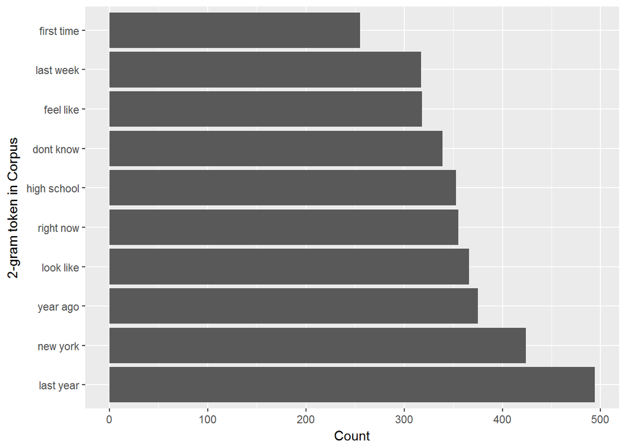

```r
m2 <- as.matrix(TDM2)
m2_dim <- dim(m2)
topTokens2gram <- sort(rowSums(m2), decreasing=TRUE)[1:N]

dfplot2 <- as.data.frame(melt(topTokens2gram))
dfplot2$token <- dimnames(dfplot2)[[1]]
dfplot2$token <- factor(dfplot2$token,
                      levels=dfplot2$token[order(dfplot2$value,
                                               decreasing=TRUE)])

fig2 <- ggplot(dfplot2, aes(x=token, y=value)) + geom_bar(stat="identity")
fig2 <- fig2 + xlab("2-gram token in Corpus")
fig2 <- fig2 + ylab("Count")
fig2 <- fig2 + coord_flip()
print(fig2)
```

#### Clustering words

The final step in our data exploratory analysis is to find clusters of words using hierarchical clustering. Sparse terms are removed in previous step, so that the plot of clustering will not be crowded with words. Then the distances between terms are calculated with `dist()` after scaling. After that, the terms are clustered with `hclust()` and the dendrogram is cut into 10 clusters. The agglomeration method is set to ward, which denotes the increase in variance when two clusters are merged.

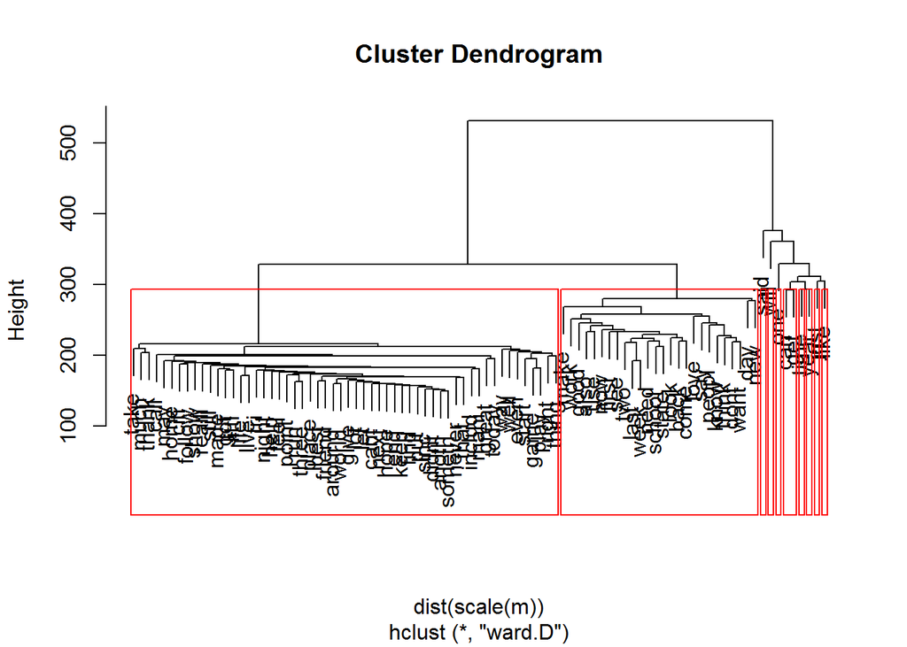

```r
HClust <- hclust(dist(scale(m)), method = "ward.D")

# plot the cluster
plot(HClust)
# cut tree into 10 clusters
rect.hclust(HClust, k=10)
```

```r
(groups <- cutree(HClust, k=10))
```

```
##   also  anoth around   back   best   call    can   cant   citi   come
##      1      2      2      1      2      2      3      2      2      1
##    day  didnt   dont    end   even   feel   find  first follow friend
##      1      2      1      2      2      2      2      1      2      2
##   game    get   give   good    got  great   help   home   hope includ
##      2      3      2      1      2      2      2      2      2      2
##   just   keep   know   last    let   life   like  littl   live   look
##      4      2      1      1      2      2      5      2      2      1
##    lot   love   made   make   mani    may   much   need  never    new
##      2      1      2      1      2      2      2      1      2      1
##   next  night    now    one  peopl  place   play  point    put realli
##      2      2      1      6      1      2      2      2      2      2
##  right    run   said    say school    see   show   sinc someth  start
##      2      2      7      1      1      1      2      2      2      2
##  state  still   take  thank   that  thing  think  three   time  today
##      1      2      2      2      2      2      1      2      8      2
##    tri    two    use   want    way   week   well   will   work  world
##      2      1      1      1      2      1      2      9      1      2
##   year
##     10
```

### Next steps

The next tasks to accomplish will be building a n-gram model for predicting the next word based on the previous 1, 2, or 3 words and another to handle unseen n-grams, and finally building the Shiny app to interact with.